# 大学院講義：微生物学 演習マニュアル

統計用プログラミング言語Rの活用法

Author

微生物学講座 円山

Published

June 4, 2026

# はじめに / Introduction

このマニュアルは、本日の講義で入力する R のコードをまとめたものです。 このマニュアルのコードを Posit Cloud の「Console」にコピー＆ペーストして実行しながら進めてください。

> This manual summarizes the R code you will enter during today’s lecture. Please proceed by copying and pasting the code from this manual into the “Console” of Posit Cloud.

## なぜ R を使うのか？（再現可能性） / Why use R? (Reproducibility)

研究において、**「再現可能性 (Reproducibility)」**は非常に重要です。同じデータから、誰がやっても同じ分析結果やグラフが得られる必要があります。 Excel では「どこをクリックしたか」の記録が残りにくいですが、R を使えば**操作がすべて「コード」として記録される**ため、後から完璧に検証・再現することができます。

> In research, **Reproducibility** is crucial. Anyone should be able to obtain the same results from the same data. While Excel doesn’t easily record “where you clicked”, R records all operations as “code”, allowing for perfect verification and reproduction later.

# 1. データの確認 / Checking data

本日は、R に最初から入っている「モルモットの歯の成長（ToothGrowth）」データを使います。

> Today, we will use the built-in “Guinea pig tooth growth (ToothGrowth)” data in R.

```r
# データの最初の6行を表示 / Show the first 6 rows
head(ToothGrowth)
```

```
   len supp dose
1  4.2   VC  0.5
2 11.5   VC  0.5
3  7.3   VC  0.5
4  5.8   VC  0.5
5  6.4   VC  0.5
6 10.0   VC  0.5
```

```r
# データの構造を確認 / Check data structure
str(ToothGrowth)
```

```
'data.frame':   60 obs. of  3 variables:
 $ len : num  4.2 11.5 7.3 5.8 6.4 10 11.2 11.2 5.2 7 ...
 $ supp: Factor w/ 2 levels "OJ","VC": 2 2 2 2 2 2 2 2 2 2 ...
 $ dose: num  0.5 0.5 0.5 0.5 0.5 0.5 0.5 0.5 0.5 0.5 ...
```

```r
# データの要約（平均値、最大・最小など） / Data summary (mean, max/min, etc.)
summary(ToothGrowth)
```

```
      len        supp         dose
 Min.   : 4.20   OJ:30   Min.   :0.500
 1st Qu.:13.07   VC:30   1st Qu.:0.500
 Median :19.25           Median :1.000
 Mean   :18.81           Mean   :1.167
 3rd Qu.:25.27           3rd Qu.:2.000
 Max.   :33.90           Max.   :2.000
```

```r
# 歯の長さ（len）の標準偏差 / Standard deviation of tooth length
sd(ToothGrowth$len)
```

```
[1] 7.649315
```

# 2. データの可視化 / Visualization

数値をグラフにして、データの特徴を視覚的に理解します。

> Visualize the numbers to understand the characteristics of the data.

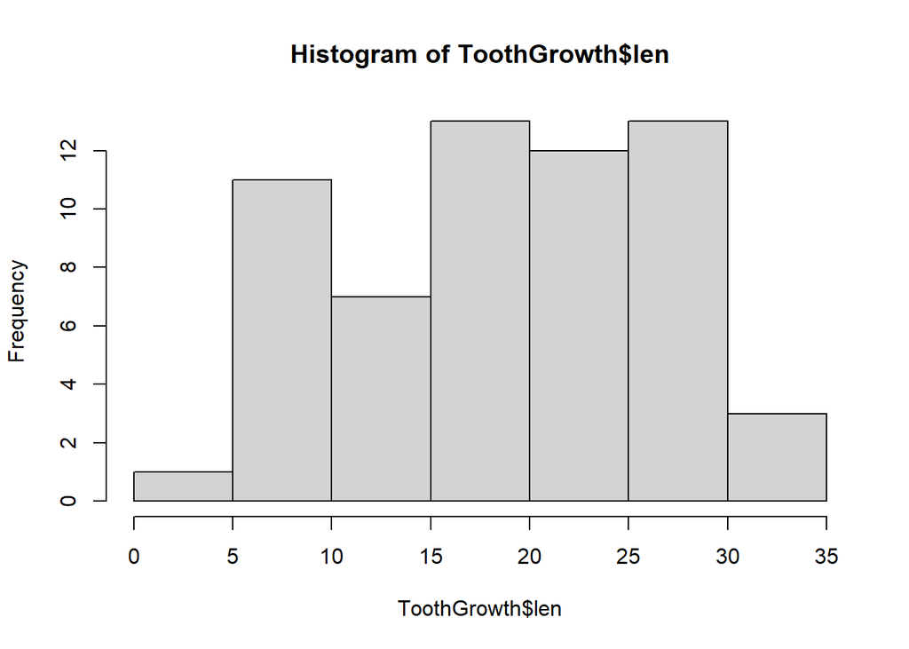

```r
# 歯の長さのヒストグラム / Histogram of tooth length
hist(ToothGrowth$len)
```

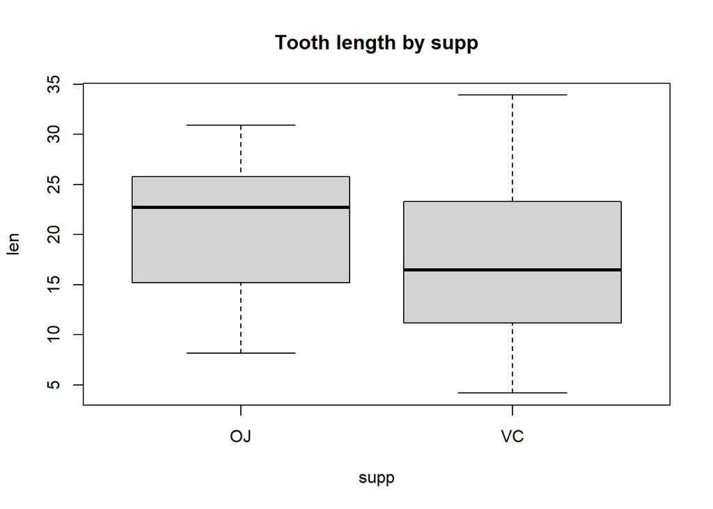

```r
# 投与方法(supp)ごとの歯の長さの箱ひげ図 / Boxplot by delivery method
boxplot(len ~ supp, data = ToothGrowth, main="Tooth length by supp")
```

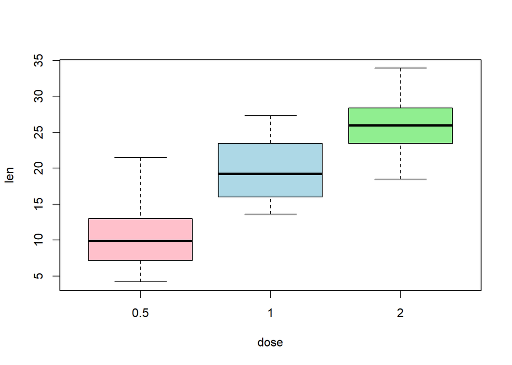

```r
# 投与量(dose)ごとの箱ひげ図に色をつける / Boxplot by dose with colors
boxplot(len ~ dose, data = ToothGrowth, col = c("pink", "lightblue", "lightgreen"))
```

# 3. 統計検定 / Statistical test

投与方法（オレンジジュースか、アスコルビン酸か）によって、歯の長さに有意な差があるかを t検定 で調べます。

> Perform a t-test to see if there is a significant difference in tooth length depending on the delivery method (orange juice or ascorbic acid).

```r
# 投与方法(supp)によるt検定 / t-test by delivery method
t.test(len ~ supp, data = ToothGrowth)
```

```
    Welch Two Sample t-test

data:  len by supp
t = 1.9153, df = 55.309, p-value = 0.06063
alternative hypothesis: true difference in means between group OJ and group VC is not equal to 0
95 percent confidence interval:
 -0.1710156  7.5710156
sample estimates:
mean in group OJ mean in group VC
        20.66333         16.96333
```

`p-value` が 0.05 より小さければ、「有意差がある（偶然ではない）」と判断します。

> If the `p-value` is less than 0.05, we determine that “there is a significant difference (not by chance)”.

# Appendix 1: 自分のデータを読み込む方法 / Loading your own data

講義後、自分の研究データ（Excel 等で作った CSV ファイル）を R で分析するための手順です。 以下の **ステップ1・ステップ2 を順番に** 実行してください。

> Steps to analyze your own research data (CSV files created in Excel, etc.) in R after the lecture. Please execute **Step 1 and Step 2 in order**.

### ステップ1：ファイルのアップロード / Step 1: Upload the file

右下の画面にある `Upload` ボタンを押し、自分の CSV ファイル（例：`mydata.csv`）をアップロードします。

> Click the `Upload` button in the bottom right window and upload your CSV file (e.g., `mydata.csv`).

### ステップ2：Rで読み込む / Step 2: Load into R

アップロードが完了したら、以下のコードを実行してデータを読み込みます。

> Once uploaded, run the following code to load the data.

```r
# データを "mydata" という名前で読み込む / Load data as "mydata"
mydata <- read.csv("mydata.csv")

# 読み込んだデータを確認する / Check the loaded data
head(mydata)
```

# Appendix 2: さらに美しいグラフを描く (ggplot2) / Advanced plotting with ggplot2

論文 (Paper) にそのまま使えるような、より高度で美しいグラフを描きたい場合は、`tidyverse` (特に `ggplot2`) というパッケージを使用します。最初は文法が少し複雑に見えますが、慣れると非常に強力です。

> To create advanced, publication-quality plots, researchers use the `tidyverse` package (specifically `ggplot2`). The syntax looks complex at first, but it is extremely powerful.

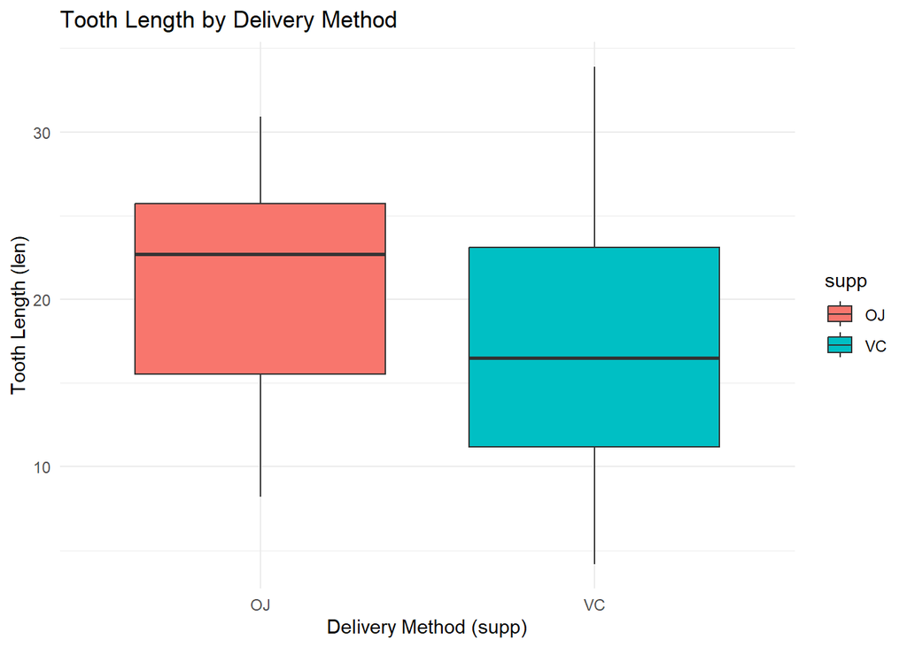

```r
# パッケージのインストール（初回のみ、少し時間がかかります）
# Install package (only needed once, takes some time)
# install.packages("tidyverse")

# パッケージを読み込む / Load the package
library(tidyverse)
# ggplot2 を使って美しい箱ひげ図を描く / Create a beautiful boxplot
ggplot(data = ToothGrowth, aes(x = supp, y = len, fill = supp)) +
  geom_boxplot() +
  labs(title = "Tooth Length by Delivery Method",
       x = "Delivery Method (supp)",
       y = "Tooth Length (len)") +
  theme_minimal()
```

# Appendix 3: 自分のPCで R を使うには / Using R on your own PC

講義では Web 上の Posit Cloud を使いましたが、自分の PC で本格的に分析を行う場合は、ソフトウェアをインストールするのが一般的です。以下の **1・2 を順番に** インストールします。

> Today we used Posit Cloud on the web. If you want to perform analysis on your own PC, you generally install the software. Please install the following **1 and 2 in order**.
1. **R (The R Project)**: 統計計算を行う「エンジン」です。単体でも動きますが、操作画面がシンプルすぎて少し使いにくいです。 > **R (The R Project)**: The “engine” that performs statistical calculations. It works on its own, but the interface is too simple and a bit hard to use. > - ダウンロード / Download: [CRAN](https://cran.r-project.org/)
2. **RStudio (Posit)**: R を圧倒的に使いやすくするための「操作画面」です。今回の Posit Cloud と全く同じ画面で操作できます。 > **RStudio (Posit)**: The “interface” that makes R overwhelmingly easier to use. It looks and works exactly like the Posit Cloud we used today. > - ダウンロード / Download: [RStudio Desktop](https://posit.co/download/rstudio-desktop/)

※ 必ず **「1. R」を先にインストールしてから、「2. RStudio」をインストール** してください。 > *Note: Be sure to **install “1. R” first, then install “2. RStudio”**.*